# Generative Pseudo-labels Refinement for Unsupervised Domain Adaptation

## Import

```python
os.chdir('./PseudoLabel/')
```

```python
import numpy as np
import torch
import torchvision
import matplotlib.pyplot as plt
from torchvision import datasets, transforms
from torch import nn, optim
from torch.autograd import Variable
import torch.nn.functional as F
import os
import PseudoLabel.CNN as Models
from torchvision import models
import PseudoLabel.Predict as predict
import PseudoLabel.cGan as cGans
import PseudoLabel.Train_cGan_NMIST as Train_cGans
```

## Description

Implémentation de l'approche Pseudo-Label Refinement pour l'apprentissage non supervisée d'un classificateur sur le dataset MNIST.

Il y a deux grandes phases successives à réaliser pour implémenter cette méthode

1. Une phase de pré-entrainement d'un classifieur C0 réalisé sur le dataset source (SVHN), ainsi que d'un cGAN GO et DO. Pour ce faire, le dataset SVHN est converti en Grayscale. Le cGAN est quant à lui entrainé sur un dataset cible MNIST bruité, c'est à dire dont les pesudo-labels sont inférés par le classifieur C0. Les dimensions du dataset MNIST sont transformées pour correspondre à celles du dataset SVHN (32x32). Aussi les données sont normalisées dans la fonction transform.
2. Une phase d'apprentissage itérative qui alterne l'apprentissage du classifieur C sur un dataset généré par le générateur G et l'apprentissage du cGAN G et D su un dataset bruité par des pseudos-labels inférés pas le classifieur C. Aussi les données sont normalisées dans la fonction transform.

## Phase 1 - Pré-entrainement C0, G0 et D0

### Prè-entrainement et performance de C0

J'ai comparé la performance de plusieurs modèles de CNN sur le dataset SVHN converti en Grayscale ( voir script CNN.py).

Evidemment le modèle dont la performance a été la meilleure est le ReNet, c'est celui quei a donc été retenu en tant que C0. L'apprentissage de ce modèle a eu lieu vi ale script Train_CNN_SVHN.py

#### Chargement de C0

```python
#Define n_channels and adequate transformation
n_channels = 1
device =torch.device('cuda:0'if torch.cuda.is_available() else 'cpu')

#Load Pretrained C0
C0=Models.ResNet(Models.ResidualBlock, num_classes=10, n_channels = n_channels)
C0.load_state_dict(torch.load('./outputs/Model_Trained_SVHN_C1.pth'))
C0.to(device)
```

```
ResNet(
  (conv1): Conv2d(1, 16, kernel_size=(3, 3), stride=(1, 1), padding=(1, 1))
  (bn): BatchNorm2d(16, eps=1e-05, momentum=0.1, affine=True, track_running_stats=True)
  (relu): ReLU()
  (block1): ResidualBlock(
    (conv1): Conv2d(16, 16, kernel_size=(3, 3), stride=(1, 1), padding=(1, 1))
    (bn1): BatchNorm2d(16, eps=1e-05, momentum=0.1, affine=True, track_running_stats=True)
    (relu): ReLU()
    (conv2): Conv2d(16, 16, kernel_size=(3, 3), stride=(1, 1), padding=(1, 1))
    (bn2): BatchNorm2d(16, eps=1e-05, momentum=0.1, affine=True, track_running_stats=True)
  )
  (block2): ResidualBlock(
    (conv1): Conv2d(16, 16, kernel_size=(3, 3), stride=(1, 1), padding=(1, 1))
    (bn1): BatchNorm2d(16, eps=1e-05, momentum=0.1, affine=True, track_running_stats=True)
    (relu): ReLU()
    (conv2): Conv2d(16, 16, kernel_size=(3, 3), stride=(1, 1), padding=(1, 1))
    (bn2): BatchNorm2d(16, eps=1e-05, momentum=0.1, affine=True, track_running_stats=True)
  )
  (block3): ResidualBlock(
    (conv1): Conv2d(16, 32, kernel_size=(3, 3), stride=(2, 2), padding=(1, 1))
    (bn1): BatchNorm2d(32, eps=1e-05, momentum=0.1, affine=True, track_running_stats=True)
    (relu): ReLU()
    (conv2): Conv2d(32, 32, kernel_size=(3, 3), stride=(1, 1), padding=(1, 1))
    (bn2): BatchNorm2d(32, eps=1e-05, momentum=0.1, affine=True, track_running_stats=True)
    (downsample): Sequential(
      (0): Conv2d(16, 32, kernel_size=(3, 3), stride=(2, 2), padding=(1, 1))
      (1): BatchNorm2d(32, eps=1e-05, momentum=0.1, affine=True, track_running_stats=True)
    )
  )
  (block4): ResidualBlock(
    (conv1): Conv2d(32, 32, kernel_size=(3, 3), stride=(1, 1), padding=(1, 1))
    (bn1): BatchNorm2d(32, eps=1e-05, momentum=0.1, affine=True, track_running_stats=True)
    (relu): ReLU()
    (conv2): Conv2d(32, 32, kernel_size=(3, 3), stride=(1, 1), padding=(1, 1))
    (bn2): BatchNorm2d(32, eps=1e-05, momentum=0.1, affine=True, track_running_stats=True)
  )
  (block5): ResidualBlock(
    (conv1): Conv2d(32, 64, kernel_size=(3, 3), stride=(2, 2), padding=(1, 1))
    (bn1): BatchNorm2d(64, eps=1e-05, momentum=0.1, affine=True, track_running_stats=True)
    (relu): ReLU()
    (conv2): Conv2d(64, 64, kernel_size=(3, 3), stride=(1, 1), padding=(1, 1))
    (bn2): BatchNorm2d(64, eps=1e-05, momentum=0.1, affine=True, track_running_stats=True)
    (downsample): Sequential(
      (0): Conv2d(32, 64, kernel_size=(3, 3), stride=(2, 2), padding=(1, 1))
      (1): BatchNorm2d(64, eps=1e-05, momentum=0.1, affine=True, track_running_stats=True)
    )
  )
  (block6): ResidualBlock(
    (conv1): Conv2d(64, 64, kernel_size=(3, 3), stride=(1, 1), padding=(1, 1))
    (bn1): BatchNorm2d(64, eps=1e-05, momentum=0.1, affine=True, track_running_stats=True)
    (relu): ReLU()
    (conv2): Conv2d(64, 64, kernel_size=(3, 3), stride=(1, 1), padding=(1, 1))
    (bn2): BatchNorm2d(64, eps=1e-05, momentum=0.1, affine=True, track_running_stats=True)
  )
  (avg_pool): AvgPool2d(kernel_size=7, stride=7, padding=0)
  (fc): Linear(in_features=64, out_features=10, bias=True)
)
```

#### Chargement et transformation du dataset SVHN

```python
if n_channels == 1:
        transform = transforms.Compose([
            transforms.Resize((32, 32)),
            transforms.Grayscale(num_output_channels=n_channels),
            transforms.ToTensor(),
            transforms.Normalize((0.5), (1.0))
        ])
else:
        transform = transforms.Compose([
            transforms.Resize((32, 32)),
            transforms.Grayscale(num_output_channels=n_channels),
            transforms.ToTensor(),
            transforms.Normalize((0.5, 0.5, 0.5), (1.0, 1.0, 1.0))
        ])


trainset = datasets.SVHN('./dataset/SVHN', split='train', transform=transform,download=True)
testset = datasets.SVHN('./dataset/SVHN', split='test', transform=transform,download=True)
batch_size=128
trainloader = torch.utils.data.DataLoader(trainset, batch_size=batch_size,shuffle=True)
testloader = torch.utils.data.DataLoader(testset, batch_size=batch_size, shuffle=True)

#Sample description
print('Number of training samples: {}'.format(len(trainset)))
print('Number of test samples: {}'.format(len(testset)))
print('sample size: {}'.format(trainset[0][0].shape))
print('image rows: {}'.format(trainset[0][0].shape[1]))
print('image cols: {}'.format(trainset[0][0].shape[2]))
print('Classes: {}'.format(np.unique(trainloader.dataset.labels)))

#Batch description
dataiter = iter(trainloader)
images, labels=dataiter.next()
print('size of batch of labels: {}'.format(labels.shape))
print('size of batch of images: {}'.format(images.shape))
```

```
Downloading http://ufldl.stanford.edu/housenumbers/train_32x32.mat to ./dataset/SVHN\train_32x32.mat
```

```
Downloading http://ufldl.stanford.edu/housenumbers/test_32x32.mat to ./dataset/SVHN\test_32x32.mat
```

```
Number of training samples: 73257
Number of test samples: 26032
sample size: torch.Size([1, 32, 32])
image rows: 32
image cols: 32
Classes: [0 1 2 3 4 5 6 7 8 9]
size of batch of labels: torch.Size([128])
size of batch of images: torch.Size([128, 1, 32, 32])
```

#### Performance de C0 sur le dataset SVHN

```python
criterion = nn.CrossEntropyLoss()
print('Performance of model C0 on grayscale SVHN dataset : {}'.format(
        predict.test( C0, testloader, criterion=criterion)))
```

```
tMSE LOSS: 0.228072 	MSE Accuracy: 0.950189
Performance of model C0 on grayscale SVHN dataset : (0.2280717924529431, 0.950188954671224)
```

#### Chargement et transformation du dataset MNIST

```python
if n_channels == 1:
    mnist_transform = transforms.Compose([
        transforms.Resize((32, 32)),
        transforms.Grayscale(num_output_channels=n_channels),
        transforms.ToTensor(),
        transforms.Normalize((0.5), (1.0))
        ])
else:
    mnist_transform = transforms.Compose([
        transforms.Resize((32, 32)),
        transforms.Grayscale(num_output_channels=n_channels),
        transforms.ToTensor(),
        transforms.Normalize((0.5, 0.5, 0.5), (1.0, 1.0, 1.0))
        ])


trainset = datasets.MNIST('./dataset/MNIST', train=True, transform=mnist_transform,download=True)
testset = datasets.MNIST('./dataset/MNIST', train=False, transform=mnist_transform,download=True)
batch_size=128
trainloader = torch.utils.data.DataLoader(trainset, batch_size=batch_size,shuffle=True)
testloader = torch.utils.data.DataLoader(testset, batch_size=batch_size, shuffle=True)
```

```
Downloading http://yann.lecun.com/exdb/mnist/train-images-idx3-ubyte.gz to ./dataset/MNIST\MNIST\raw\train-images-idx3-ubyte.gz
```

```
Extracting ./dataset/MNIST\MNIST\raw\train-images-idx3-ubyte.gz to ./dataset/MNIST\MNIST\raw
Downloading http://yann.lecun.com/exdb/mnist/train-labels-idx1-ubyte.gz to ./dataset/MNIST\MNIST\raw\train-labels-idx1-ubyte.gz
```

```
Extracting ./dataset/MNIST\MNIST\raw\train-labels-idx1-ubyte.gz to ./dataset/MNIST\MNIST\raw
Downloading http://yann.lecun.com/exdb/mnist/t10k-images-idx3-ubyte.gz to ./dataset/MNIST\MNIST\raw\t10k-images-idx3-ubyte.gz
```

```
Extracting ./dataset/MNIST\MNIST\raw\t10k-images-idx3-ubyte.gz to ./dataset/MNIST\MNIST\raw
Downloading http://yann.lecun.com/exdb/mnist/t10k-labels-idx1-ubyte.gz to ./dataset/MNIST\MNIST\raw\t10k-labels-idx1-ubyte.gz
```

```
Extracting ./dataset/MNIST\MNIST\raw\t10k-labels-idx1-ubyte.gz to ./dataset/MNIST\MNIST\raw
Processing...
Done!
```

#### Performance de C0 sur le dataset MNIST

```python
criterion = nn.CrossEntropyLoss()
print('Performance of model C0 on grayscale SVHN dataset : {}'.format(
        predict.test( C0, testloader, criterion=criterion)))
```

```
tMSE LOSS: 1.261677 	MSE Accuracy: 0.670392
Performance of model C0 on grayscale SVHN dataset : (1.261677319490457, 0.6703916139240507)
```

On constate que le classifieur CO basé sur l'architecture ResNet obtient des performances de :

95% sur le dataset SVHN converti en grayscale,

67% sur le dataset MNIST transformé en dimension 32x32.

A noter que l'apprentissage du classifieur C0 a eu lieu uniquement sur les données SVHN, ce qui explique ses résultats préliminaires sur le dataset MNIST.

### Prè-entrainement et performance d'un cGAN G0 et D0

De la même manière il a fallu construire et développer un cGan sur le dataset MNIST transformé en 32 x 32 pixels. Lors du développement de ce cGan j’ai rencontré plusieurs problématiques notamment des problèmes de divergence des « loss » très marquées et de « collapse ». Afin de résoudre ces problématiques j’ai dû :

Implémenter une approche de « label smoothing »,

Introduire un bruit gaussien dans les images réelles et fausses en entrée du discriminateur D avec un decay,

Implémenter un "flip" de 5% des labels positifs et négatifs en entrée du discriminateur,

Implémenter un cDCGAN et complexifier les modèles G et D en ajoutant des convolutions et des « Batch Normalisation »et des « Spectral normalisation ». L’idée était de développer un générateur suffisamment fin pour et avec un contraste suffisamment qualitatif pour générer des images de qualités suffisantes.

Ces approches ont permis de stabiliser l'apprentissage du cGan et d'éviter l'effondrement de la perte du discriminant D et la dérive de la perte du générateur G. j’ai constaté de manière empirique, c’est-à-dire de manière visuelle, que la performance de du générateur était acceptable entre 15 et 25 epochs, tout en restant pas trop long à implémenter.

#### Chargement des modèles G0 et D0 pré-entrainés

```python
#dimensions
z_dim = 100
n_classes = 10
images_dim = trainset[0][0].shape[1] * trainset[0][0].shape[2]
batch_size = 128

#models G0 et D0
G0 = cGans.Generator_S(g_input_dim = z_dim, n_channels = n_channels, n_classes = n_classes)
G0.load_state_dict(torch.load('./outputs/G0_MNIST.pth'))
G0.to(device)

D0 = cGans.Discriminator_S(images_dim, n_channels = n_channels, n_classes = n_classes)
D0.load_state_dict(torch.load('./outputs/D0_MNIST.pth'))
D0.to(device)
```

```
Discriminator_S(
  (label_emb): Embedding(10, 50)
  (fc_emb): Linear(in_features=50, out_features=1024, bias=True)
  (conv1): Conv2d(2, 64, kernel_size=(5, 5), stride=(2, 2), padding=(2, 2), padding_mode=replicate)
  (conv2): Conv2d(64, 128, kernel_size=(5, 5), stride=(2, 2), padding=(2, 2), padding_mode=replicate)
  (conv3): Conv2d(128, 128, kernel_size=(5, 5), stride=(1, 1), padding=(2, 2), padding_mode=replicate)
  (dro): Dropout(p=0.3, inplace=False)
  (fla): Flatten(start_dim=1, end_dim=-1)
  (fc): Linear(in_features=8192, out_features=1, bias=True)
  (BN1): BatchNorm2d(64, eps=1e-05, momentum=0.1, affine=True, track_running_stats=True)
  (BN2): BatchNorm2d(128, eps=1e-05, momentum=0.1, affine=True, track_running_stats=True)
)
```

#### Exemples d'images générées par cGAN0

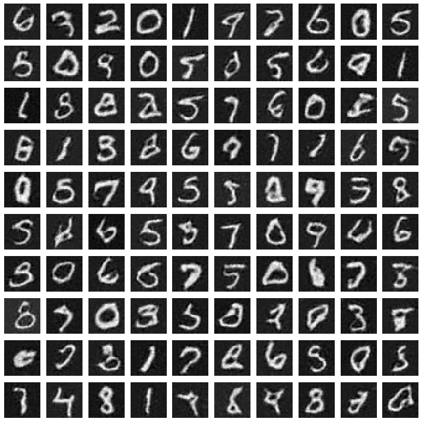

```python
dim=(10, 10)
figsize=(10, 10)
with torch.no_grad():
    test_z = Variable(torch.randn(batch_size, z_dim).to(device))
    test_label = Variable(torch.randint(0, n_classes, (batch_size,)).to(device))
    generated = G0(test_z, test_label)
    generatedImages = generated.view(generated.size(0), n_channels, 32, 32).cpu().permute(0,2,3,1).numpy()
plt.figure(figsize=figsize)
for i in range(100):
    plt.subplot(dim[0], dim[1], i+1)
    plt.imshow(np.squeeze(generatedImages[i]), interpolation='nearest', cmap='gray')
    plt.axis('off')
plt.tight_layout()
```

## Phase 2 - Apprentissage itératif de C, G et D

Durant cette phase, les modèles C, G et D font l'objet d'étapes d'apprentissage itératives. Lors de la première itération les modèles C, G et D correspondent aux modèles C0, G0 et D0.

L'étape 2.1 consiste à générer un dataset MNIST « cible » via le générateur conditionnel "G". Les labels des images sont tirés suivant une loi uniforme parmi les 10 classes disponibles. Les images conditionnelles et ces labels constitue un dataset « cible » qui permet d’affiner l'ap-prentissage du classifieur C.

L’étape 2.2 consiste à affiner les modèles cGan G et D. Le dataset utilisé pour l'apprentissage est un échantillon aléatoire d'images du dataset MNIST dont les labels sont inférés par le classi-fieur C. J’ai décidé de conserver 25 epochs pour l’apprentissage du cGAN dans cette phase. Mon code me permet de générer des images à chaque epoch et ainsi de vérifier visuellement que les images générées sont acceptables.

En alternant ses deux étapes, l'asymétrie du bruit initial diminue et la performance du modèle C sur le dataset MNIST, et ce, alors que l'apprentissage se déroule de manière non supervisée. J'ai mis en œuvre cette approche sur 10 itérations. A chaque étape, 7680 échantillons sont tirés de ma-nière aléatoire pour les étapes d’apprentissage du classifieur C (2.1) et du conditionnel Gan G (2.2).

Le code utilise pour implémenter ces itérations est retranscrit dans le script « PseudoLabelmain.py ».

### Chargement des modèles finaux cGAN G et D

```python
#models G et D
G = cGans.Generator_S(g_input_dim = z_dim, n_channels = n_channels, n_classes = n_classes)
G.load_state_dict(torch.load('./outputs/G_MNIST.pth'))
G.to(device)

D = cGans.Discriminator_S(images_dim, n_channels = n_channels, n_classes = n_classes)
D.load_state_dict(torch.load('./outputs/D_MNIST.pth'))
D.to(device)
```

```
Discriminator_S(
  (label_emb): Embedding(10, 50)
  (fc_emb): Linear(in_features=50, out_features=1024, bias=True)
  (conv1): Conv2d(2, 64, kernel_size=(5, 5), stride=(2, 2), padding=(2, 2), padding_mode=replicate)
  (conv2): Conv2d(64, 128, kernel_size=(5, 5), stride=(2, 2), padding=(2, 2), padding_mode=replicate)
  (conv3): Conv2d(128, 128, kernel_size=(5, 5), stride=(1, 1), padding=(2, 2), padding_mode=replicate)
  (dro): Dropout(p=0.3, inplace=False)
  (fla): Flatten(start_dim=1, end_dim=-1)
  (fc): Linear(in_features=8192, out_features=1, bias=True)
  (BN1): BatchNorm2d(64, eps=1e-05, momentum=0.1, affine=True, track_running_stats=True)
  (BN2): BatchNorm2d(128, eps=1e-05, momentum=0.1, affine=True, track_running_stats=True)
)
```

### Exemples d'images générées par le modèle cGan final

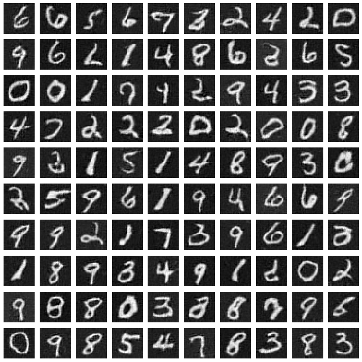

```python
dim=(10, 10)
figsize=(10, 10)
with torch.no_grad():
    test_z = Variable(torch.randn(batch_size, z_dim).to(device))
    test_label = Variable(torch.randint(0, n_classes, (batch_size,)).to(device))
    generated = G(test_z, test_label)
    generatedImages = generated.view(generated.size(0), n_channels, 32, 32).cpu().permute(0,2,3,1).numpy()
plt.figure(figsize=figsize)
for i in range(100):
    plt.subplot(dim[0], dim[1], i+1)
    plt.imshow(np.squeeze(generatedImages[i]), interpolation='nearest', cmap='gray')
    plt.axis('off')
plt.tight_layout()
```

### Chargement du classifieur final C

```python
#Load Pretrained C
C=Models.ResNet(Models.ResidualBlock, num_classes=10, n_channels = n_channels)
C.load_state_dict(torch.load('./outputs/C_MNIST_CNN.pth'))
C.to(device)
```

```
ResNet(
  (conv1): Conv2d(1, 16, kernel_size=(3, 3), stride=(1, 1), padding=(1, 1))
  (bn): BatchNorm2d(16, eps=1e-05, momentum=0.1, affine=True, track_running_stats=True)
  (relu): ReLU()
  (block1): ResidualBlock(
    (conv1): Conv2d(16, 16, kernel_size=(3, 3), stride=(1, 1), padding=(1, 1))
    (bn1): BatchNorm2d(16, eps=1e-05, momentum=0.1, affine=True, track_running_stats=True)
    (relu): ReLU()
    (conv2): Conv2d(16, 16, kernel_size=(3, 3), stride=(1, 1), padding=(1, 1))
    (bn2): BatchNorm2d(16, eps=1e-05, momentum=0.1, affine=True, track_running_stats=True)
  )
  (block2): ResidualBlock(
    (conv1): Conv2d(16, 16, kernel_size=(3, 3), stride=(1, 1), padding=(1, 1))
    (bn1): BatchNorm2d(16, eps=1e-05, momentum=0.1, affine=True, track_running_stats=True)
    (relu): ReLU()
    (conv2): Conv2d(16, 16, kernel_size=(3, 3), stride=(1, 1), padding=(1, 1))
    (bn2): BatchNorm2d(16, eps=1e-05, momentum=0.1, affine=True, track_running_stats=True)
  )
  (block3): ResidualBlock(
    (conv1): Conv2d(16, 32, kernel_size=(3, 3), stride=(2, 2), padding=(1, 1))
    (bn1): BatchNorm2d(32, eps=1e-05, momentum=0.1, affine=True, track_running_stats=True)
    (relu): ReLU()
    (conv2): Conv2d(32, 32, kernel_size=(3, 3), stride=(1, 1), padding=(1, 1))
    (bn2): BatchNorm2d(32, eps=1e-05, momentum=0.1, affine=True, track_running_stats=True)
    (downsample): Sequential(
      (0): Conv2d(16, 32, kernel_size=(3, 3), stride=(2, 2), padding=(1, 1))
      (1): BatchNorm2d(32, eps=1e-05, momentum=0.1, affine=True, track_running_stats=True)
    )
  )
  (block4): ResidualBlock(
    (conv1): Conv2d(32, 32, kernel_size=(3, 3), stride=(1, 1), padding=(1, 1))
    (bn1): BatchNorm2d(32, eps=1e-05, momentum=0.1, affine=True, track_running_stats=True)
    (relu): ReLU()
    (conv2): Conv2d(32, 32, kernel_size=(3, 3), stride=(1, 1), padding=(1, 1))
    (bn2): BatchNorm2d(32, eps=1e-05, momentum=0.1, affine=True, track_running_stats=True)
  )
  (block5): ResidualBlock(
    (conv1): Conv2d(32, 64, kernel_size=(3, 3), stride=(2, 2), padding=(1, 1))
    (bn1): BatchNorm2d(64, eps=1e-05, momentum=0.1, affine=True, track_running_stats=True)
    (relu): ReLU()
    (conv2): Conv2d(64, 64, kernel_size=(3, 3), stride=(1, 1), padding=(1, 1))
    (bn2): BatchNorm2d(64, eps=1e-05, momentum=0.1, affine=True, track_running_stats=True)
    (downsample): Sequential(
      (0): Conv2d(32, 64, kernel_size=(3, 3), stride=(2, 2), padding=(1, 1))
      (1): BatchNorm2d(64, eps=1e-05, momentum=0.1, affine=True, track_running_stats=True)
    )
  )
  (block6): ResidualBlock(
    (conv1): Conv2d(64, 64, kernel_size=(3, 3), stride=(1, 1), padding=(1, 1))
    (bn1): BatchNorm2d(64, eps=1e-05, momentum=0.1, affine=True, track_running_stats=True)
    (relu): ReLU()
    (conv2): Conv2d(64, 64, kernel_size=(3, 3), stride=(1, 1), padding=(1, 1))
    (bn2): BatchNorm2d(64, eps=1e-05, momentum=0.1, affine=True, track_running_stats=True)
  )
  (avg_pool): AvgPool2d(kernel_size=7, stride=7, padding=0)
  (fc): Linear(in_features=64, out_features=10, bias=True)
)
```

### Performance du classifieur C finale sur le dataset MNIST

```python
criterion = nn.CrossEntropyLoss()
print('Performance of model C0 on grayscale SVHN dataset : {}'.format(
        predict.test( C, testloader, criterion=criterion)))
```

```
tMSE LOSS: 0.276352 	MSE Accuracy: 0.934830
Performance of model C0 on grayscale SVHN dataset : (0.2763515424124802, 0.9348299050632911)
```

J'obtiens donc une accuracy de 93,5% du classifieur C sur le dataset MNIST avec l'approche PLR. Le papier d'origine annonce une performance de l'ordre de 97%.

On remarque que la performance du modèle a évolué de 67% à 93,5% avec cette méthode. On peut donc considérer cette approche comme performante.